# Peer-graded Assignment

areeves

July 9, 2017

## Loading and preprocessing the data

Loaded and transformed the csv with the following code:

```r
d<-read.csv("activity.csv")
d$date<-as.Date(as.character(d$date),"%Y-%m-%d")
```

## What is mean total number of steps taken per day?

Calculate total steps by date and store in variable “daily.steps”. Plot histogram of daily.steps.

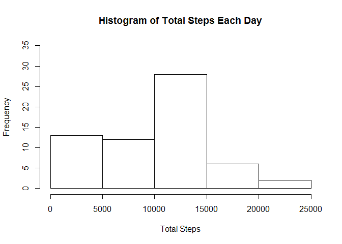

```r
daily.steps<-tapply(d$steps,d$date,sum,na.rm=TRUE)
hist(daily.steps,ylim=c(0,35),main="Histogram of Total Steps Each Day",
     xlab="Total Steps")
```

The mean and median daily steps are:

```r
mean(daily.steps)
```

```
## [1] 9354.23
```

```r
median(daily.steps)
```

```
## [1] 10395
```

## What is the average daily activity pattern?

Time-series of the mean number of steps taken by 5-minute interval.

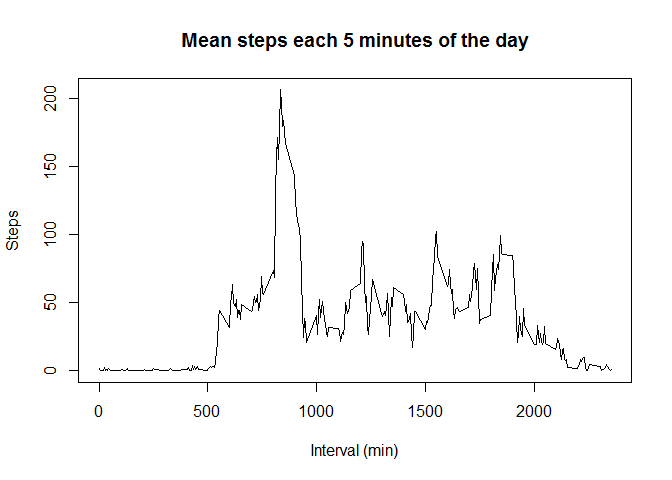

```r
interval.steps<-tapply(d$steps,d$interval,mean,na.rm=TRUE)
plot(names(interval.steps),interval.steps,type="l",
     xlab = "Interval (min)", ylab = "Steps",
     main = "Mean steps each 5 minutes of the day")
```

The 5-minute interval that contains the maximum number of steps is:

```r
names(interval.steps)[which.max(interval.steps)]
```

```
## [1] "835"
```

## Imputing missing values

The number of incomplete rows in the dataset is

```r
sum(!complete.cases(d))
```

```
## [1] 2304
```

The missing data were imputed with the following code.

```r
d.imp<-d
d.imp$steps<- sapply(1:nrow(d),function(i) ifelse(is.na(d[i,1]), interval.steps[names(interval.steps)==d[i,3]], d[i,1]) )
```

Histogram of the daily step total with imputed data:

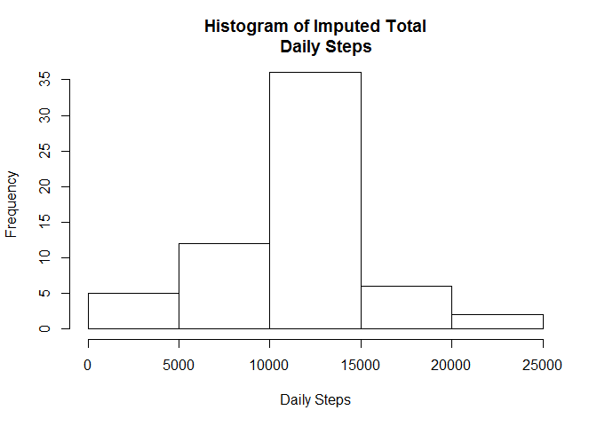

```r
daily.steps.imp<-tapply(d.imp$steps,d.imp$date,sum,na.rm=TRUE)
hist(daily.steps.imp,ylim=c(0,35),main = "Histogram of Imputed Total
     Daily Steps", xlab = "Daily Steps")
```

The mean and median daily steps are:

```r
mean(daily.steps.imp)
```

```
## [1] 10766.19
```

```r
median(daily.steps.imp)
```

```
## [1] 10766.19
```

The histogram and mean both show a shift toward the median relative to the non-imputed data. In other words, there is less skew. This makes sense since we used a mean-based calculation to impute missing data.

## Are there differences in activity patterns between weekdays and weekends?

Create new factor variable for weekday vs weekend. Calculate mean number of steps by 5 minute interval and weekday/end. Store result in matrix “m”.

```r
d.imp$day<-weekdays(d.imp$date)
d.imp$day<-as.factor(d.imp$day)
levels(d.imp$day)<-list(
        "weekday" = c("Monday","Tuesday","Wednesday","Thursday", "Friday"),
        "weekend" = c("Saturday","Sunday"))
m<-tapply(d.imp$steps,list(d.imp$interval,d.imp$day),mean)
```

Make a panel plot of weekday and weekend step activity by 5 minute interval.

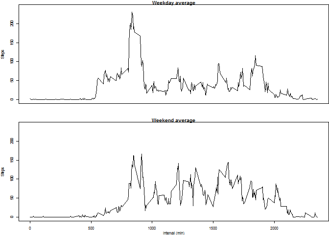

```r
par(mfrow=c(2,1),mar=c(3, 4, 1, 0), cex=0.5)
plot(rownames(m),m[,1],
              main="Weekday average",
              xlab="", xaxt='n',
              ylab="Steps", ylim = c(0,240),
              type="l")
par(mar=c(3,4,1,0))
plot(rownames(m),m[,2],
              main="Weekend average",
              xlab="",
              ylab="Steps", ylim = c(0,240),
              type="l")
title(xlab="Interval (min)",line=2,cex.lab=1)
```